# Python Exercise Collection 2

This notebook contains exercises on the numpy material we covered during week 3. There are ~25 problems here of somewhat increasing difficulty. The hardest exercises are beyond the difficulty level of what we'd put on a quiz, but may be close to what you might need to do for a lab report figure. For some of these questions there are multiple ways to get the answer, so don't feel like the provided solutions are the only way to do it.  
Unless asked to, **do not** create any arrays by writing `np.array([])` and filling in the list with numbers.

### Exercise 1

Import the `numpy` package under its correct alias

```python
# Your code here
import numpy as np
```

```python
# You can ignore this cell, just run it before continuing.
# The code insures that everyone should have the same
# random numbers for the problems in this notebook
np.random.seed(42)
```

### Exercise 2

Create an array filled with zeros of size 10. Do not just fill `np.array()` with a list of zeros.

```python
# Your code here
zero_arr = np.zeros(shape=10)
print(zero_arr, zero_arr.shape)
```

```
[0. 0. 0. 0. 0. 0. 0. 0. 0. 0.] (10,)
```

### Exercise 3

Make the last element of the array from the previous problem equal to 1

```python
# Your code here
zero_arr[-1] = 1
print(zero_arr)
```

```
[0. 0. 0. 0. 0. 0. 0. 0. 0. 1.]
```

### Exercise 4

Create and display a 1-dimensional numpy array containing the integers ranging from 10 to 49

```python
# Your code here
arr = np.arange(10, 50)
print(arr)
```

```
[10 11 12 13 14 15 16 17 18 19 20 21 22 23 24 25 26 27 28 29 30 31 32 33
 34 35 36 37 38 39 40 41 42 43 44 45 46 47 48 49]
```

### Exercise 5

Using the same array from the previous problem, reshape it to have 10 rows and four columns.

```python
# Your code here
reshaped_arr = arr.reshape(10, 4)
print(reshaped_arr)
```

```
[[10 11 12 13]
 [14 15 16 17]
 [18 19 20 21]
 [22 23 24 25]
 [26 27 28 29]
 [30 31 32 33]
 [34 35 36 37]
 [38 39 40 41]
 [42 43 44 45]
 [46 47 48 49]]
```

### Exercise 6

Using the same array from the previous problem, create and display a new array which contains only the values in the last two rows and last two columns. Your answer should look like this $\begin{bmatrix}44 & 45 \\ 48 & 49 \end{bmatrix}$ except it'll appear as a list of lists rather than as a matrix.

```python
# Your code here
last_two = reshaped_arr[-2:, -2:]
print(last_two)
```

```
[[44 45]
 [48 49]]
```

### Exercise 7

With the array you obtained in the previous problem, replace all even values with 0 and odd values with 1 only using numpy operations, no for loops.

```python
# Your code here
even_odd = last_two % 2
print(even_odd)
```

```
[[0 1]
 [0 1]]
```

### Exercise 8

Using the array you made on exercise 5, create and display a new array containing only the elements which are divisible by 5.

```python
# Your code here
divisible_by_five = reshaped_arr[reshaped_arr % 5 == 0]
print(divisible_by_five)
```

```
[10 15 20 25 30 35 40 45]
```

### Exercise 9

Use numpy to generate an array of size (10, 10) with random numbers between 0 and 1.

```python
# Your code here
random_array = np.random.rand(10, 10)
print(random_array)
print(random_array.shape)
```

```
[[0.37454012 0.95071431 0.73199394 0.59865848 0.15601864 0.15599452
  0.05808361 0.86617615 0.60111501 0.70807258]
 [0.02058449 0.96990985 0.83244264 0.21233911 0.18182497 0.18340451
  0.30424224 0.52475643 0.43194502 0.29122914]
 [0.61185289 0.13949386 0.29214465 0.36636184 0.45606998 0.78517596
  0.19967378 0.51423444 0.59241457 0.04645041]
 [0.60754485 0.17052412 0.06505159 0.94888554 0.96563203 0.80839735
  0.30461377 0.09767211 0.68423303 0.44015249]
 [0.12203823 0.49517691 0.03438852 0.9093204  0.25877998 0.66252228
  0.31171108 0.52006802 0.54671028 0.18485446]
 [0.96958463 0.77513282 0.93949894 0.89482735 0.59789998 0.92187424
  0.0884925  0.19598286 0.04522729 0.32533033]
 [0.38867729 0.27134903 0.82873751 0.35675333 0.28093451 0.54269608
  0.14092422 0.80219698 0.07455064 0.98688694]
 [0.77224477 0.19871568 0.00552212 0.81546143 0.70685734 0.72900717
  0.77127035 0.07404465 0.35846573 0.11586906]
 [0.86310343 0.62329813 0.33089802 0.06355835 0.31098232 0.32518332
  0.72960618 0.63755747 0.88721274 0.47221493]
 [0.11959425 0.71324479 0.76078505 0.5612772  0.77096718 0.4937956
  0.52273283 0.42754102 0.02541913 0.10789143]]
(10, 10)
```

### Exercise 10

Find the max, min, mean, standard deviation, and median of the array you made on the previous problem.

```python
# Your code here
print(random_array.max())
print(random_array.min())
print(random_array.mean())
print(random_array.std())
print(np.median(random_array)) # Unfortunately the syntax for median is slightly different
```

```
0.9868869366005173
0.005522117123602399
0.47018074337820936
0.29599822663249037
0.4641424546894926
```

### Exercise 11

Use numpy to find the row and column position of the maximum element in your random array. Double check your work by indexing the array with your answer.

```python
# Your code here
max_position = np.unravel_index(np.argmax(random_array), shape=random_array.shape)
print(max_position)
print(random_array.max() == random_array[max_position])
```

```
(6, 9)
True
```

### Exercise 12

```python
# Your code here
five_by_five_arr = np.arange(1, 26).reshape(5, 5)
inner_arr = five_by_five_arr[1:-1, 1:-1]
print(inner_arr)
```

```
[[ 7  8  9]
 [12 13 14]
 [17 18 19]]
```

### Exercise 13

Create a (6, 4) array with values ranging from 1 to 24. Then, without using for loops, find the values **and** positions of array elements for which both 4 and 6 are perfect factors? Double check your work by using your positions to index the array.

```python
four_by_four = np.arange(1, 25).reshape(6, 4)
perfect_factors = four_by_four[(four_by_four % 4 == 0) & (four_by_four % 6 == 0)]
perfect_factor_positions = np.argwhere((four_by_four % 4 == 0) & (four_by_four % 6 == 0))
print(four_by_four)
print('Perfect factors:', perfect_factors)
print('Positions:\n', perfect_factor_positions)

# When using np.argwhere, each row corresponds to a position where the conditional is true
# This can lead to some confusing indexing sometimes, so just make sure you know the shape
# of every array you are working with
print(four_by_four[perfect_factor_positions[0, 0], perfect_factor_positions[0, 1]])
print(four_by_four[perfect_factor_positions[1, 0], perfect_factor_positions[1, 1]])
```

```
[[ 1  2  3  4]
 [ 5  6  7  8]
 [ 9 10 11 12]
 [13 14 15 16]
 [17 18 19 20]
 [21 22 23 24]]
Perfect factors: [12 24]
Positions:
 [[2 3]
 [5 3]]
12
24
```

### Exercise 14

Use `np.linspace()` to make an array which starts at 0 and goes to 5 in 0.25 increments.

```python
increments_to_five = np.linspace(start=0, stop=5, num=21)
print((increments_to_five))
```

```
[0.   0.25 0.5  0.75 1.   1.25 1.5  1.75 2.   2.25 2.5  2.75 3.   3.25
 3.5  3.75 4.   4.25 4.5  4.75 5.  ]
```

### Exercise 15

Define a variable `x` and use `np.linspace()` to make it an array ranging from 0 to $2\pi$ in $\frac{\pi}{4}$ increments. Use `np.pi` to refer to $\pi$

```python
# Your code here
x = np.linspace(0, 2 * np.pi, 9)
print(x)
```

```
[0.         0.78539816 1.57079633 2.35619449 3.14159265 3.92699082
 4.71238898 5.49778714 6.28318531]
```

### Exercise 16

Using your variable `x` from the previous exercise, compute $\sin($`x`$)$

```python
# Your code here
sin_of_x = np.sin(x)
print(sin_of_x)
```

```
[ 0.00000000e+00  7.07106781e-01  1.00000000e+00  7.07106781e-01
  1.22464680e-16 -7.07106781e-01 -1.00000000e+00 -7.07106781e-01
 -2.44929360e-16]
```

### Exercise 17

Write a function that implements the Gaussian function: $f(x)=e^{-x^2}$. (Note: Give your function a more descriptive name than $f$ when you write your code!)

```python
def gauss(x):
    return np.exp(-x**2)
```

### Exercise 18

Modify the function from the previous exercise to take in parameters $a,b,c$ so that $f(x,a,b,c)=ae^{-(x-b)^2+c}$.

```python
def gauss(x,a,b,c):
    return a*np.exp(-(x-b)**2+c)
```

### Exercise 19

Create a 1D array with 10000 values evenly spaced between $-1$ and $2$, and then reshape it to be a $100\times 100$ array. Then apply your Gaussian function from the previous exercise to this array, with $a=10$, $b=1$, and $c=2$. Note: You should not need to do anything special to apply your Gaussian function to this 2D array.

```python
grid = np.linspace(-1,2,10000).reshape(100,100)
arr = gauss(grid,10,1,2)
```

### Exercise 20

Find the maximum of the previous matrix (the Gaussian function applied to the 2D array) and its (unraveled) index.

```python
print(np.max(arr))
print(np.argwhere(arr==np.max(arr))[0])
```

```
73.89056098930651
[66 66]
```

### Exercise 21

Create a `9x9` array of zeros, and then fill row 5, column 5, and the main diagonal (top left to bottom right) with ones. No for loops. Hint: `np.diag_indices(n)` will give you the indices of the diagonal for an $n\times n$ array.

```python
arr = np.zeros((9,9))
arr[4] = 1
arr[:,4] = 1
arr[np.diag_indices(9)] = 1
```

### Exercise 22

Now take the array from the previous problem and fill the main skew diagonal (the longest diagonal going from the bottom left to the top right) with ones. Hint: There isn't a function like `np.diag_indices` for skew-diagonals, but you can rotate the array with `np.rot90` to turn the skew diagonal into a diagonal, modify the array, and then rotate it back. Check out the documentation of `np.rot90` here: https://numpy.org/doc/stable/reference/generated/numpy.rot90.html to find out how to use it.

```python
arr = np.rot90(arr)
arr[np.diag_indices(9)] = 1
arr = np.rot90(arr,-1)
print(arr)
```

```
[[1. 0. 0. 0. 1. 0. 0. 0. 1.]
 [0. 1. 0. 0. 1. 0. 0. 1. 0.]
 [0. 0. 1. 0. 1. 0. 1. 0. 0.]
 [0. 0. 0. 1. 1. 1. 0. 0. 0.]
 [1. 1. 1. 1. 1. 1. 1. 1. 1.]
 [0. 0. 0. 1. 1. 1. 0. 0. 0.]
 [0. 0. 1. 0. 1. 0. 1. 0. 0.]
 [0. 1. 0. 0. 1. 0. 0. 1. 0.]
 [1. 0. 0. 0. 1. 0. 0. 0. 1.]]
```

### Exercise 23

Create a 3D array of random numbers called `data` with shape $50\times 1000\times 3$. Next, cCreate an evenly spaced array of values between 0 and $8\pi$ with length 1000 and call that `t`. Then **add** `np.sin(t)` to the first $50\times 100$ array in `data` from the previous problem (i.e. `data[:,:,0]`). Next **add** `np.cos(t)` to the next $50\times 1000$ array, and finally **add** `np.tanh(t-12)` to the last $50\times 1000$ array.

```python
data = np.random.rand(50,1000,3)
t = np.linspace(0,8*np.pi,1000)
data[:,:,0] += np.sin(t)
data[:,:,1] += np.cos(t)
data[:,:,2] += np.tanh(t-12)
```

### Exercise 24

Average the previous array along the 1st axis, leaving you with an array with shape $1000\times 3$, and save the result to `trial_averaged`. Then run the code below.

[output not shown]

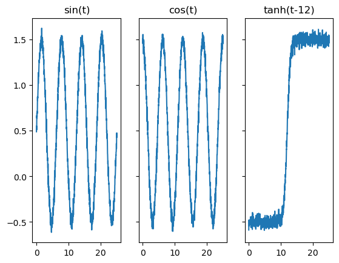

```python
trial_averaged = np.mean(data,axis=0)

import matplotlib.pylab as plt
fig,ax = plt.subplots(1,3,sharex=True,sharey=True)
[ax[i].plot(t,trial_averaged[:,i]) for i in range(3)]
[ax[i].set_title(title) for i,title in enumerate(["sin(t)","cos(t)","tanh(t-12)"])]
```

### Exercise 25

Compute the standard deviation of `data` along the 1st axis, save it to `trial_std`, and then run the code below.

[output not shown]

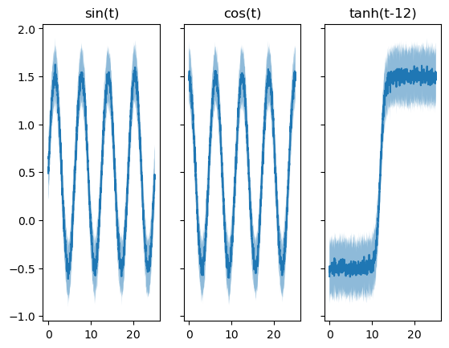

```python
trial_std = np.std(data,axis=0)

import matplotlib.pylab as plt
fig,ax = plt.subplots(1,3,sharex=True,sharey=True)
[ax[i].plot(t,trial_averaged[:,i]) for i in range(3)]
[ax[i].fill_between(t,trial_averaged[:,i]-trial_std[:,i],trial_averaged[:,i]+trial_std[:,i],alpha=0.5) for i in range(3)]
[ax[i].set_title(title) for i,title in enumerate(["sin(t)","cos(t)","tanh(t-12)"])]
```